# Análisis del gasto total del Gobierno Central en Costa Rica entre 2007 y 2018 mediante series de tiempo

24 de octubre de 2018

## Índice

- Introducción
- Metodología
- Resultados
- Conclusiones

## Introducción

## Introducción

- ¿Que es el gasto total del Gobierno Central?
- Relación del gasto del gobierno con el déficit fiscal
- Importancia de estudiar el gasto del gobierno central

## Objetivo

- Generar predicciones sobre el gasto total del Gobierno Central en Costa Rica, de manera mensual y a un horizonte a medio plazo, con el fin de brindar información importante para la toma de decisiones con respecto a las finanzas públicas en el futuro

## Materiales y métodos

## Materiales

- La fuente de los datos es la Contraloría General de la República
- Datos sobre el gasto total del Gobierno Central, de forma mensual, desde enero del 2007 hasta junio del 2018
- Datos en millones de colones nominales, por lo que se tienen que deflatar
- Se parte el conjunto de datos en dos:
1. Conjunto de entrenamiento: de enero del 2007 a junio del 2016
2. Conjunto de prueba: de julio del 2016 a junio del 2018

## Métodos

- Se hicieron cuatro modelos:
1. Regresión con tendencia y estacionalidad
2. Modelo Holt-Winters aditivo (ETS(A,A,A))
3. Modelo ARIMA(0,1,1)(2,1,0)12
4. Modelo ARIMA(0,1,1)(2,1,0)12 con intervención
- Medidas de rendimiento:
1. RMSE
2. MAE
3. MAPE
4. MASE

## Resultados

[interactive chart not shown]

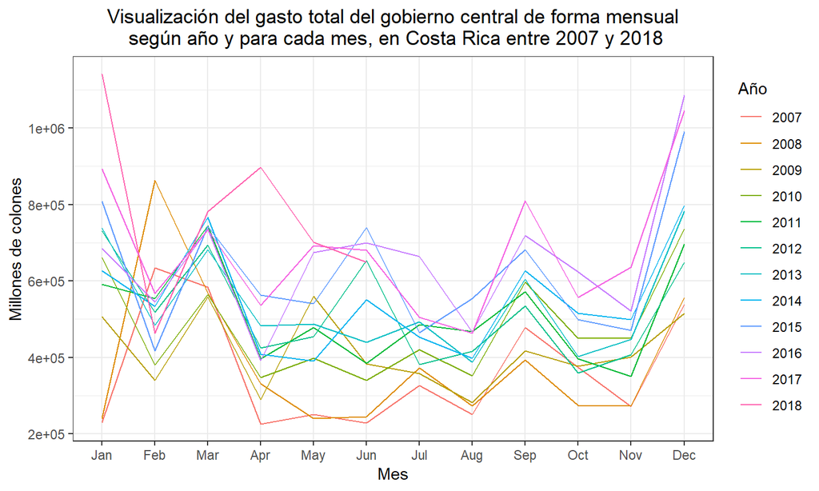

[interactive chart not shown]

| Modelo | RMSE | MAE | MAPE | MASE |
| --- | --- | --- | --- | --- |
| T+E: Entrenamiento | 90051.06 | 64025.08 | 14.292 | 0.749 |
| T+E: Prueba | 145555.08 | 110213.47 | 15.052 | 1.289 |
| HW: Entrenamiento | 91153.12 | 65545.81 | 14.919 | 0.767 |
| HW: Prueba | 150178.06 | 113049.72 | 15.130 | 1.322 |
| ARIMA: Entrenamiento | 90370.07 | 61347.16 | 12.899 | 0.717 |
| ARIMA: Prueba | 126035.01 | 94830.72 | 12.720 | 1.109 |
| ARIMA int: Entrenamiento | 89041.43 | 59293.58 | 12.475 | 0.693 |
| ARIMA int: Prueba | 127969.62 | 94445.46 | 12.571 | 1.105 |

[interactive chart not shown]

## Conclusiones y discusión

## Conclusiones

- El estudio del gasto público puede dar materiales para la introspección sobre las finanzas públicas y la deuda fiscal creciente en el pais, además de predicciones a corto y mediano plazo
- Ambos modelos ARIMA tuvieron resultados muy parecidos, aunque el ARIMA con intervención tuvo, en general, mejores medidas de rendimiento. Los modelos de regresión y Holt-Winters fueron considerablemente peores

## Discusión

- Dado que el modelo escogido para hacer las preducciones es un ARIMA con intervención, se debe volver a evaluar frecuentemente si ha habido un nuevo cambio de nivel ya que, de ser así, lo más apropiado debería ser volver a calcular el modelo
- Por la crisis fiscal en la que se encuentra el país, el Ministerio de Haciendo ha hecho una política de "cero crecimiento" en las instituciones públicas. Por lo tanto, se esperaría que el crecimiento del gasto se detenga, lo cual puede ayudar a solventar el problema, pero el modelo no es capaz de predecir esto.